# Resilienz-Architekturen

Cyber Security Management · Termin 3

Prof. Dr. Dirk Loomans

Hochschule Mainz · dirk.loomans@hs-mainz.de

## Agenda

- Rückblick & Lernziele
- Einstieg: Ein Update legt die Welt lahm
- Vier technische Resilienzprinzipien
- Redundanz – und ihre Grenzen
- Diversität gegen Kaskadenfehler
- Wiederherstellbarkeit: Recovery ≠ Backup
- Adaptivität und Chaos Engineering
- Hybridarchitekturen und ihre SPOFs
- Fallbeispiel & Übung: SPOFs finden
- Kernpunkte & Ausblick

## Rückblick Sitzung 2

- Resilienz ist **messbar**: RTO und RPO als Zielgrößen, MTTR und MTBF als Messwerte.
- Die Degradationskurve zeigt Tiefe (Δ) und Dauer (tR) einer Störung.
- Frameworks (NIST, ISO/IEC 27031, BSI 200-4, ENISA) geben Ordnung und Verbindlichkeit.
- Reifegradmodelle bewerten die Fähigkeit **vor** dem Ereignis.

**Messung allein reicht nicht – Resilienz muss im Design entstehen.**

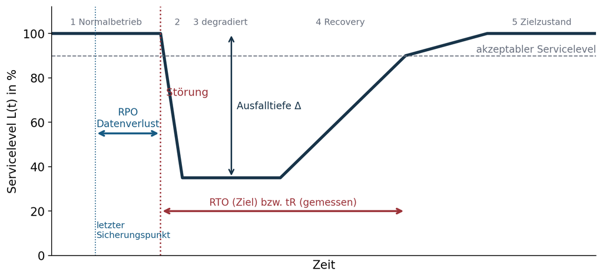

## Lernziele

Nach dieser Sitzung können Sie …

- die vier technischen Resilienzprinzipien **Redundanz, Diversität, Wiederherstellbarkeit und Adaptivität** erklären und voneinander abgrenzen,
- den Unterschied zwischen **Redundanz und Diversität** an einem Common-Mode-Failure begründen,
- erläutern, warum **Recovery eine Fähigkeit und kein Plan** ist,
- Chancen und Risiken **hybrider Architekturen** (On-Prem + Cloud) bewerten,
- **Single Points of Failure** in realen Systemen identifizieren und einem Gegenprinzip zuordnen.

## Einstieg: Ein Update legt die Welt lahm

- **19. Juli 2024:** CrowdStrike verteilt ein fehlerhaftes Konfigurations-Update für seinen Windows-Sensor
- Rund **8,5 Mio. Windows-Rechner** stürzen ab – laut Microsoft weniger als 1 % aller Windows-Geräte
- Flughäfen, Krankenhäuser, Banken und Sender stehen still; viele Rechner müssen **von Hand** repariert werden
- Hochverfügbare Cluster helfen nicht: Alle Knoten hatten **denselben Agenten**

**Frage:** Warum schützt Redundanz hier nicht?

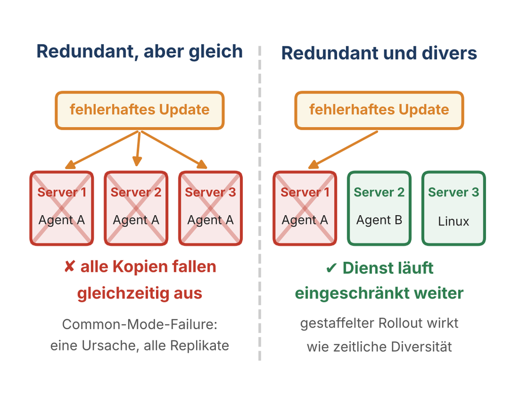

## Vier technische Resilienzprinzipien

1. **Redundanz** – keine einzelnen Bruchpunkte
2. **Diversität** – keine gemeinsamen Fehlerursachen
3. **Wiederherstellbarkeit** – geübte, getestete Rückkehrfähigkeit
4. **Adaptivität** – dynamische Reaktion statt starrer Stabilität

Messgrößen machen Resilienz sichtbar – Prinzipien erzeugen sie im Design.

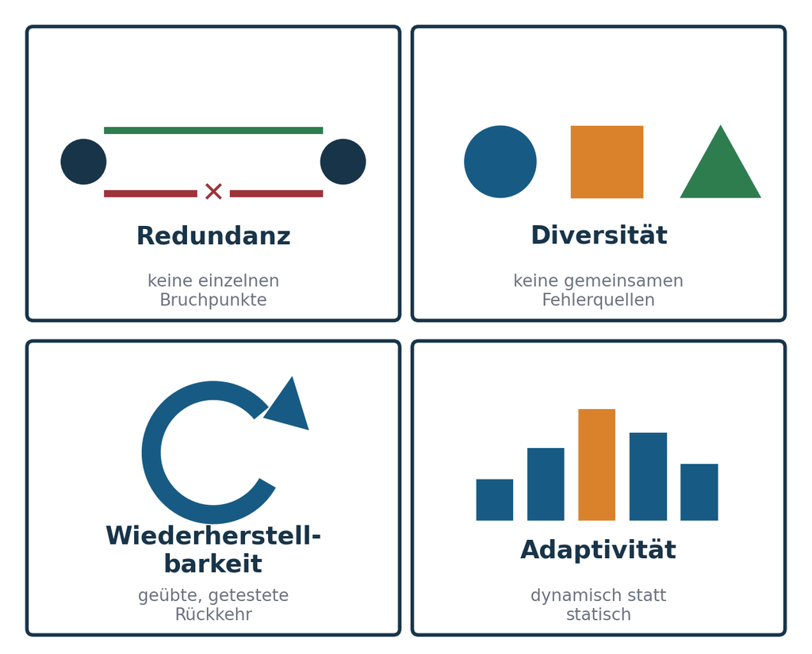

## Von der Messung zum Design

- **Redundanz, Diversität, Adaptivität** machen den Einbruch flacher (kleineres Δ).
- **Wiederherstellbarkeit** macht die Erholung schneller (kürzeres tR).
- Keines der Prinzipien wirkt allein – erst das Zusammenspiel verändert die Kurve.

Resilienz entsteht im Design, nicht im Incident.

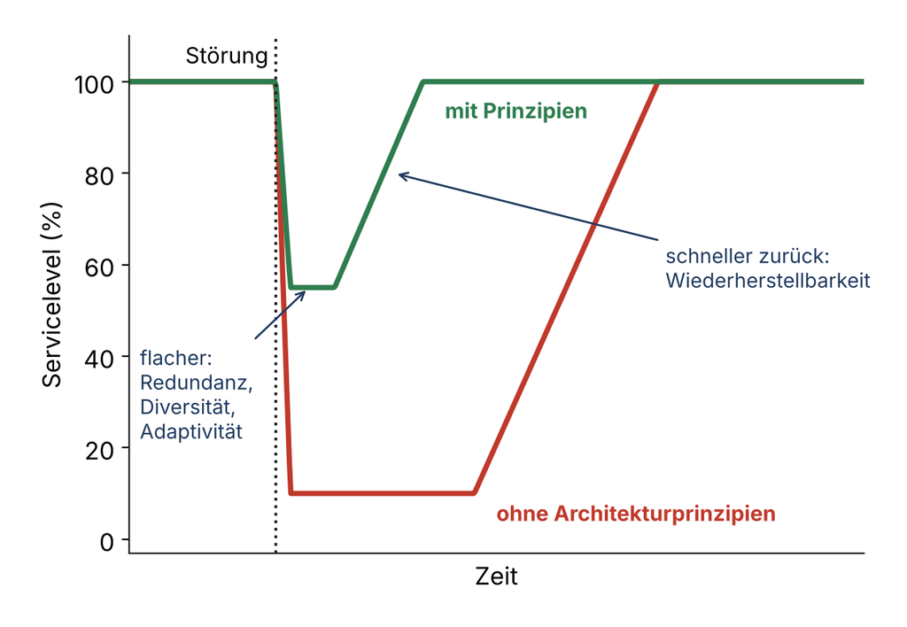

## Redundanz: On-Prem vs. Cloud

**On-Prem:** Dual Power, USV, Diesel · redundante Core-Switches und ISP-Wege · Cluster (SQL AlwaysOn, VMware HA) · zweites RZ als Cold/Warm/Hot Standby

**Cloud:** Multi-AZ-Deployment · Load Balancing + Auto-Scaling · Cross-Region-Failover

On-Prem wird Redundanz vorgehalten (CapEx), in der Cloud gebucht (OpEx): **kaufbar, aber nicht automatisch vorhanden.**

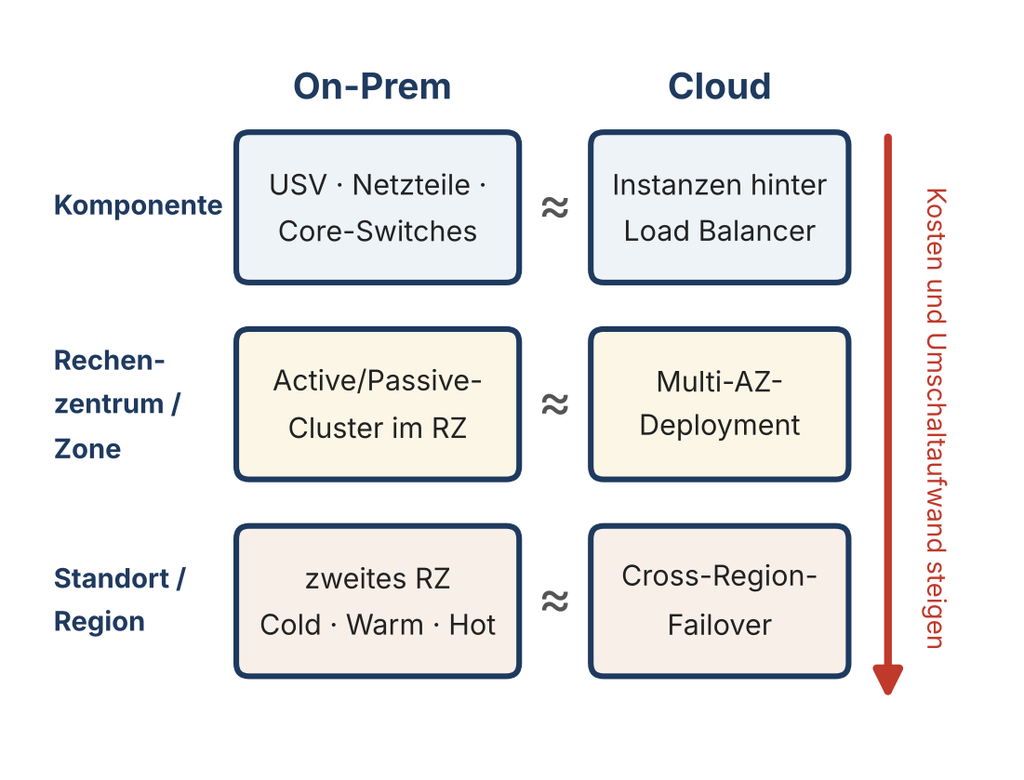

## Grenzen der Redundanz

Redundanz schützt nur gegen **komponentielle Ausfälle** – nicht gegen

- logische oder Konfigurationsfehler (CrowdStrike),
- konzertierte Angriffe (Ransomware, Wiper),
- gemeinsame Abhängigkeiten (zentrales AD),
- ungetestete Umschaltprozesse.

Zwei USVs im selben Brandabschnitt sind Redundanz ohne Isolation.

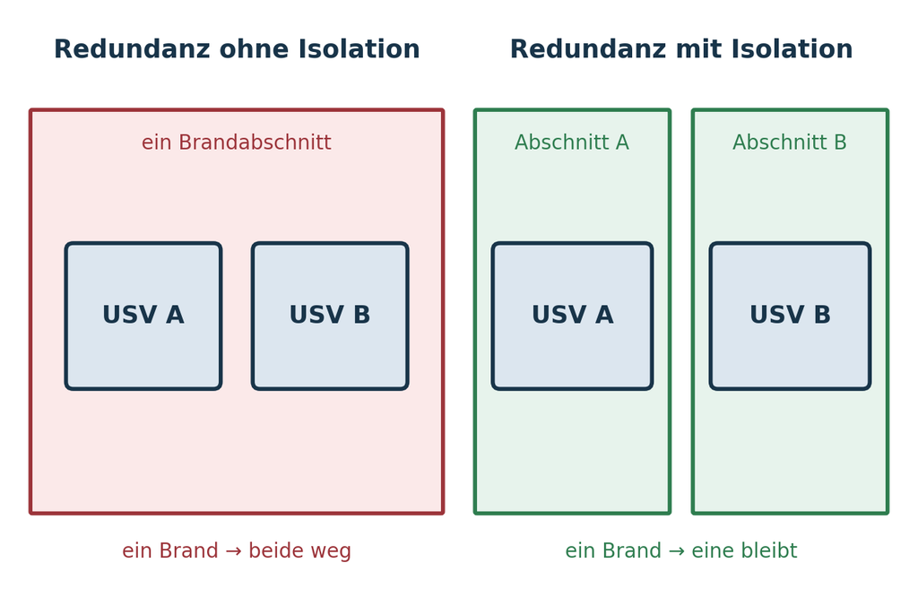

## Fallbeispiel: British Airways 2017

- **27. Mai 2017, Pfingstwochenende:** Ein Techniker trennt im Rechenzentrum bei Heathrow die Stromversorgung
- Beim Wiederzuschalten beschädigt eine **Überspannung** die IT-Systeme
- Die Ausweichsysteme übernehmen nicht – Check-in, Gepäck und Flugplanung fallen aus
- **479 Flüge** allein am ersten Tag gestrichen, mindestens 75.000 Passagiere betroffen, Kosten geschätzt bis 100 Mio. €

**Redundanz war vorhanden – die Umschaltung hat versagt.**

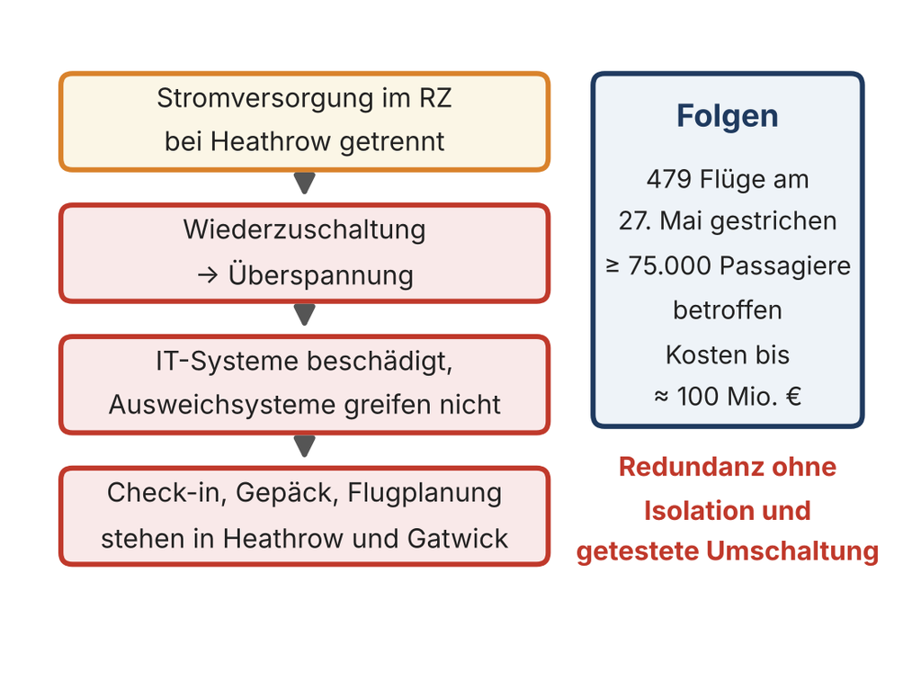

## Diversität: Schutz vor Kaskadenfehlern

Redundant, aber homogen = **gemeinsame Schwachstellen**. Diversität verhindert synchrone Ausfälle.

- **Komponenten:** verschiedene HSMs, CA-Stacks, Backup-Verfahren
- **Lieferanten:** Multi-Vendor-Firewalls, Multi-Cloud, mehrere IdPs
- **Technologie:** unterschiedliche Betriebssysteme, Container und VM, heterogener Storage
- **Zeit:** gestaffelte Rollouts (Canary) statt alles auf einmal

[figure not shown]

## Diversität kostet – und versichert

- **Kosten:** mehr Know-how, mehr Verträge, mehr Integrationsaufwand
- **Nutzen:** Versicherung gegen seltene Ereignisse mit großer Wirkung
- Ein divers aufgebauter Stack wirkt wie ein **Brandschott** gegen seitliche Ausbreitung
- NIST SP 800-160 Vol. 2 und ISO/IEC 27031 behandeln Diversität als Architekturprinzip – als **Mechanismus der Risikostreuung**, nicht als Kostenfaktor

Mehr Vielfalt heißt nicht automatisch mehr Resilienz: Jede zusätzliche Technologie ist auch eine zusätzliche Fehlerquelle.

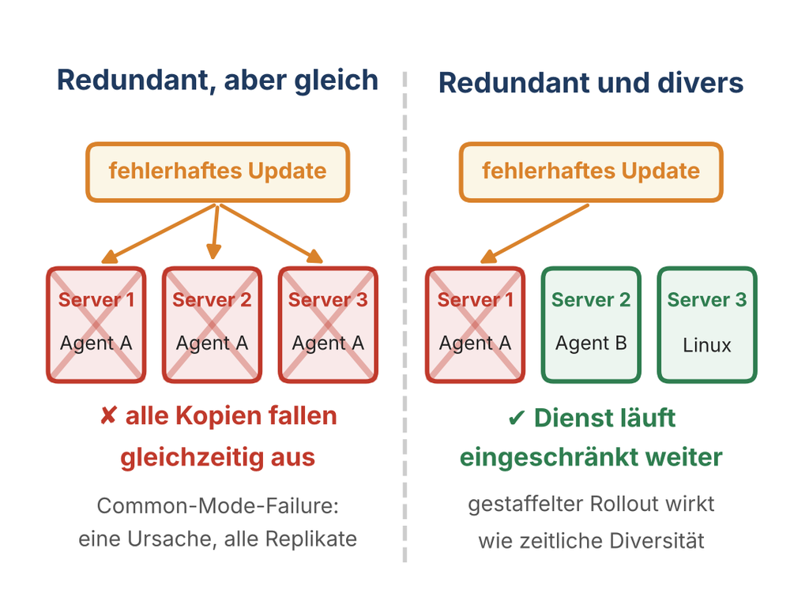

## Wiederherstellbarkeit: Recovery ≠ Backup

- **Backup** ist ein Zustand, **Recovery** ein Prozess mit Zeit- und Qualitätszielen (RTO, RPO).
- Ein ungetestetes Backup ist kein Nachweis, sondern eine Hypothese.
- Technische Mittel: Infrastructure as Code, Snapshots und Immutable Backups, Runbooks und SOAR, Failover.
- Entscheidend ist die **Validierung durch Test und Metrik**.

Die meisten Resilienzversagen entstehen nicht durch fehlende Daten, sondern durch fehlgeschlagene Wiederanläufe.

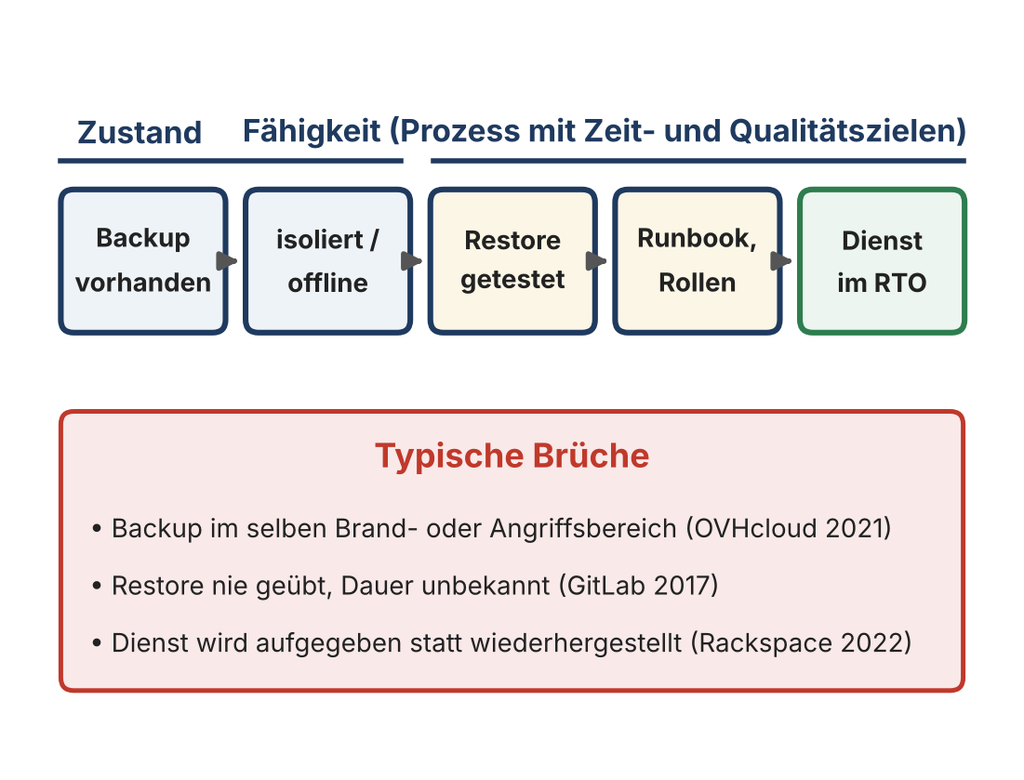

## Recovery ist eine Fähigkeit, kein Dokument

BSI-Standard 200-4 und ISO/IEC 27031 verlangen

- **Recovery-Tests** statt bloßer Planexistenz,
- **regelmäßige Notfallübungen**,
- Verzahnung von **Technik und Prozess**,
- **Lessons-Learned-Zyklen**, die die Pläne anpassen.

Ein ungeübter Plan ist funktional gleichbedeutend mit keinem Plan.

[figure not shown]

## Fallbeispiel: Rackspace 2022

- **November 2022:** Microsoft veröffentlicht einen Patch für die Exchange-Lücke „ProxyNotShell“; Rackspace setzt aus Sorge vor Anmeldeproblemen nur Workarounds ein
- **2. Dezember 2022:** Die Ransomware-Gruppe Play umgeht die Workarounds und legt Hosted Exchange lahm
- **Januar 2023:** Rackspace stellt den Dienst **ein** und migriert die Kunden zu Microsoft 365

**Recovery ist auch eine Kostenentscheidung – manchmal lautet sie: Wir bauen nicht wieder auf.**

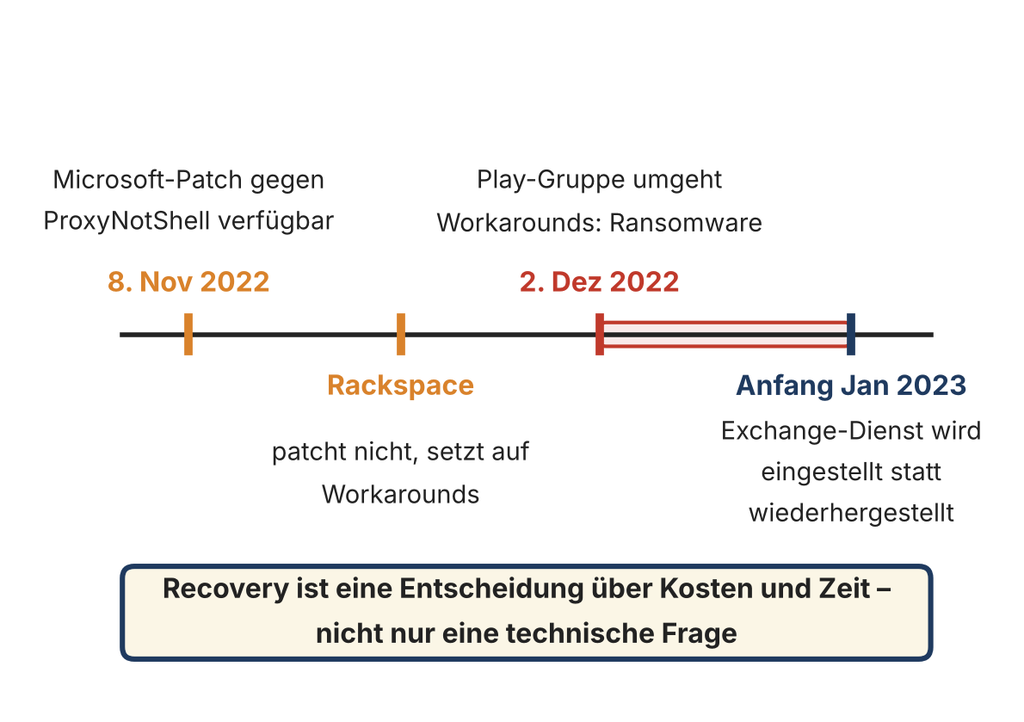

## Adaptivität: dynamische Resilienz

Stabilität hält einen Zustand – Resilienz **konfiguriert sich unter Störung neu**.

- **Auto-Scaling** gegen Lastspitzen und Knotenverluste
- **Graceful Degradation**: Funktionen reduzieren statt Totalausfall
- **Feature Flags, Circuit Breaker, Canary Releases** zur kontrollierten Drosselung
- **Traffic Shifting, Anycast, Failover-Logik** zur Neuverteilung

Ergebnis: abgestufte Überlebensfähigkeit statt „an oder aus“.

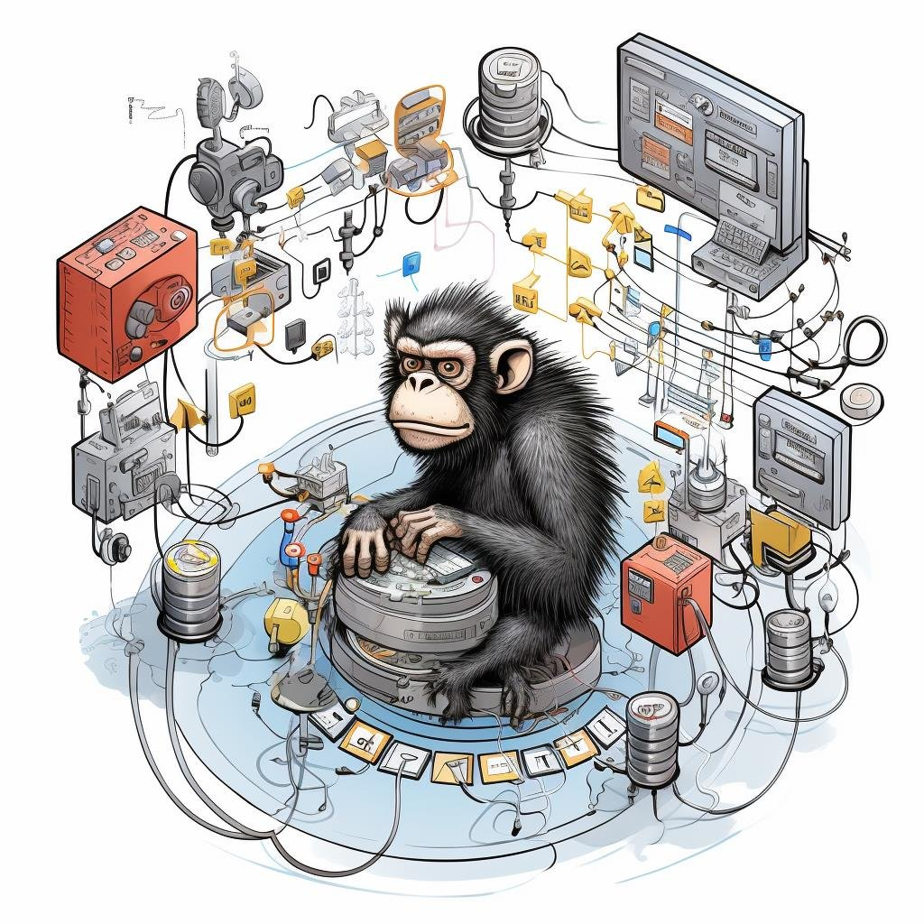

## Fallbeispiel: Netflix und Chaos Monkey

- **21. April 2011:** Störung in einer Zone der AWS-Region US-East – viele bekannte Dienste offline
- Netflix läuft weiter, mit höherer Fehlerrate und Latenz: zustandslose Dienste, **drei aktive Zonen**, Reservekapazität
- **Chaos Monkey** beendet im Betrieb zufällig Instanzen – Ausfall wird Routine
- Aber: Einen **ganzen Zonenausfall** hatte niemand geübt – die Umleitung lief teils manuell

**Resilienz entsteht nicht durch Erwartung, sondern durch Exposition.**

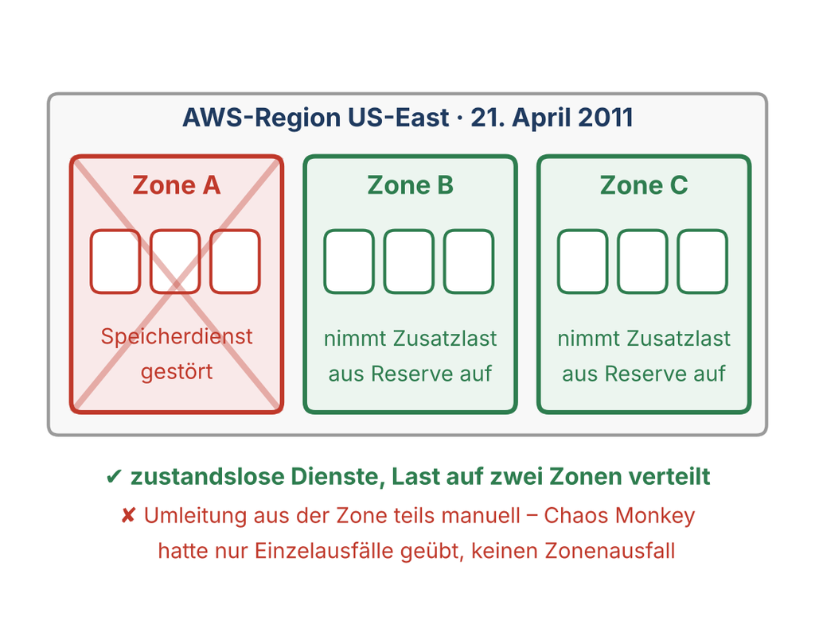

## Grenzen der Adaptivität

- Adaptivität ersetzt **weder Redundanz noch Diversität**.
- Ein adaptives System auf einem gemeinsamen Identitäts- oder Datensinglepoint adaptiert nur **innerhalb der Fragilität**.
- Automatik kann einen Fehler auch **verstärken** – AWS 2021 begann mit einer automatischen Skalierung.

Adaptivität ist ein Multiplikator, kein Ersatz.

[figure not shown]

## Hybridarchitekturen: Was ändert sich?

Hybrid erhöht den Suchraum der Fragilität – und den Werkzeugkasten der Resilienz.

| Prinzip | On-Prem | Cloud |
| --- | --- | --- |
| Redundanz | Hardware-Duplikation | Region- und AZ-Abstraktion |
| Diversität | manuell geplant | Provider oder Multi-Cloud |
| Recovery | Runbooks + Menschen | IaC + Automatisierung |
| Adaptivität | begrenzt | nativ (Scaling, Traffic Shift) |

## Hybrid-SPOFs: die Steuerungsebene

Hybride Systeme scheitern selten an Rechenleistung, sondern an **zentralen Kopplungspunkten**:

- **Identity** (AD, IdP) als globaler Fail-Knopf
- **Netzwerk-Transit** (VPN, SD-WAN) als Engpass
- **Orchestrierung, CI/CD** als einzige Steuerungsschicht
- **Echtzeit-Datenkopplung** mit engen Synchronisationszwängen

Funktional verteilt, steuerungstechnisch monolithisch = fragil.

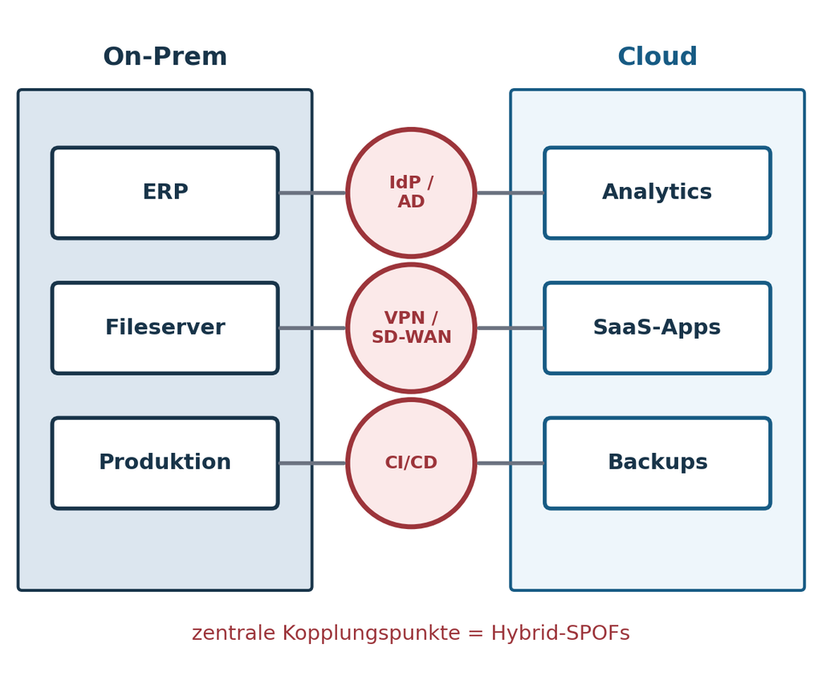

## Fallbeispiel: Facebook 2021

- **4. Oktober 2021:** Ein Wartungsbefehl trennt versehentlich alle Backbone-Verbindungen; ein Fehler im Prüfwerkzeug stoppt ihn nicht
- Die DNS-Server ziehen ihre BGP-Routen zurück – **wie vorgesehen**
- Facebook, Instagram und WhatsApp sind rund **sechs Stunden** weltweit unerreichbar
- Auch interne Werkzeuge und Fernzugriff fallen aus – Techniker müssen **vor Ort** ins Rechenzentrum, Sicherheitsmaßnahmen verzögern den Zugang

**Der SPOF lag nicht in den Servern, sondern im Management-Pfad.**

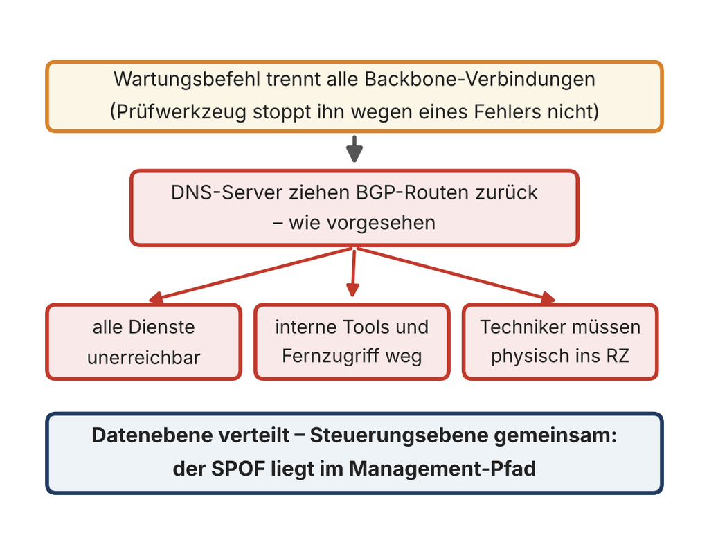

## Häufige Resilienz-Irrtümer in der Praxis

Jeder Irrtum verwechselt eine Komponente mit einer Fähigkeit – die Fälle zeigen es.

| Irrtum | Gegenbeispiel |
| --- | --- |
| „Wir sind in der Cloud, also sicher.“ | AWS 2021: Single-Region-Kunden offline |
| „Backup = Resilienz.“ | OVHcloud 2021, GitLab 2017 |
| „Cluster = Disaster Recovery.“ | CrowdStrike 2024: alle Knoten gleich |
| „Dokumentiert, aber nie getestet.“ | British Airways 2017 |
| „Wir haben ja ein Notfallteam.“ | Facebook 2021: kein Zugang ohne Netz |

## Fallbeispiel: Hybrid-Störung

**Szenario:** ERP läuft On-Prem · Reporting und Analytics laufen in der Cloud

**Vorfall:** AD-Domain-Controller On-Prem durch Ransomware kompromittiert

**Folgen:** Cloud-Analytics technisch verfügbar – aber kein Login möglich

- Was bleibt funktional, und warum?
- Wo sitzt der eigentliche SPOF?
- Welche Maßnahme hätte die Resilienz verbessert?

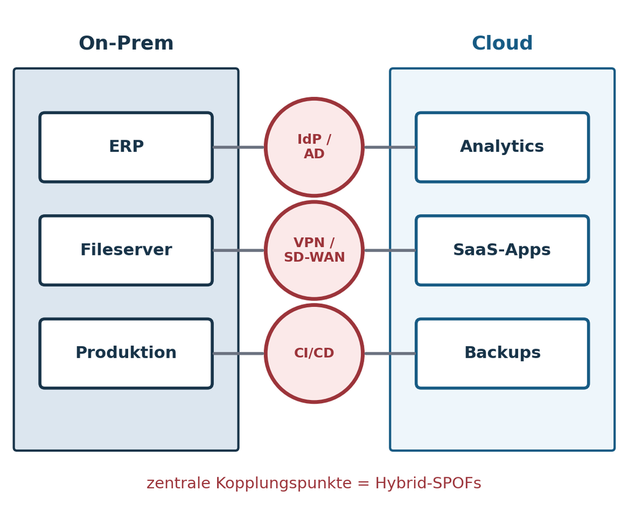

## Übung: SPOFs identifizieren & zuordnen

Gruppen, 20–30 Minuten. Wählt ein reales System: Cloud-Drive, Banking-App, Campus-E-Mail, Smart-Home-Plattform, Krankenhaus-IT.

1. Identifiziert **mindestens drei SPOFs** (z. B. IdP, Netz-Backbone, zentraler Storage, CI/CD-Pipeline).
2. Ordnet jedem SPOF ein **Gegenprinzip** zu: Redundanz, Diversität, Wiederherstellbarkeit oder Adaptivität.
3. Formuliert pro SPOF **eine realistische Maßnahme** – praktisch plausibel, keine Wunschlösung.

Ergebnis: eine Folie oder ein 5-Punkte-Statement pro Gruppe.

## Raster für die Übung

Das Raster hilft, die drei Schritte der Übung festzuhalten.

| SPOF | Warum Bruchpunkt? | Gegenprinzip | Maßnahme |
| --- | --- | --- | --- |
| 1 |  |  |  |
| 2 |  |  |  |
| 3 |  |  |  |

## Ausblick & Hausaufgabe

**Nächste Sitzung:** Bedrohungen und Resilienzstrategien – wie lassen sich Angriffe auf Widerstands- und Recovery-Muster abbilden?

**Hausaufgabe:** Nehmen Sie Ihr System aus der Übung. Welcher Ihrer SPOFs wäre für einen Angreifer am attraktivsten – und warum?

Kapitel zum Termin · Skript · Glossar · Quellen